# Regression

David Favela Corella

##SVM Regression

SVM regression allows for creating a model for prediction not based on classification.It tries to find the relationship between parameters. Its strengths include flexibility, as it allows to change the cost of the algorithm and the gamma, if using the radial kernel.

In this notebook, we will go over the SVM results, as well as the results created by the regular linear regression model.

as a recap, linear regression works by plotting X and Y and finding a relationship between them.

To begin, we get the data from the csv file. We are going to be working with covid-19 data.

#Getting the data

```r
df <- read.csv("covid_19.csv", header=TRUE)
str(df)
```

```
'data.frame':   18424 obs. of  9 variables:
 $ Country.Region: chr  "Argentina" "Australia" "Australia" "Australia" ...
 $ Lat           : num  -38.4 -35.5 -33.9 -12.5 -27.5 ...
 $ Long          : num  -63.6 149 151.2 130.8 153 ...
 $ Date          : chr  "1/22/2020" "1/22/2020" "1/22/2020" "1/22/2020" ...
 $ Confirmed     : int  0 0 0 0 0 0 0 0 0 0 ...
 $ Deaths        : int  0 0 0 0 0 0 0 0 0 0 ...
 $ Recovered     : int  0 0 0 0 0 0 0 0 0 0 ...
 $ Active        : int  0 0 0 0 0 0 0 0 0 0 ...
 $ WHO.Region    : chr  "Americas" "Western Pacific" "Western Pacific" "Western Pacific" ...
```

Then we clean and separate the data. We are going to use the Confirmed, Deaths, and Active columns for the data analysis. In this case, there’s no cleaning as I made sure the data had no null values.

```r
df <- df[,c(8,5,6)]
df$Confirmed <- as.integer(df$Confirmed)
df$Deaths <- as.integer(df$Deaths)
df$Active <- as.integer(df$Active)
dim(df)
```

```
[1] 18424     3
```

```r
head(df)
```

|  | Active | Confirmed | Deaths |
| --- | --- | --- | --- |
| 1 | 0 | 0 | 0 |
| 2 | 0 | 0 | 0 |
| 3 | 0 | 0 | 0 |
| 4 | 0 | 0 | 0 |
| 5 | 0 | 0 | 0 |
| 6 | 0 | 0 | 0 |

```r
str(df)
```

```
'data.frame':   18424 obs. of  3 variables:
 $ Active   : int  0 0 0 0 0 0 0 0 0 0 ...
 $ Confirmed: int  0 0 0 0 0 0 0 0 0 0 ...
 $ Deaths   : int  0 0 0 0 0 0 0 0 0 0 ...
```

Data is then plotted. We plot confirmed cases against deaths and active cases against deaths.

```r
par(mfrow=c(1,2))
plot(df$Deaths~df$Confirmed, xlab="Confirmed", ylab="Deaths")
abline(lm(df$Deaths~df$Confirmed), col="red")
```

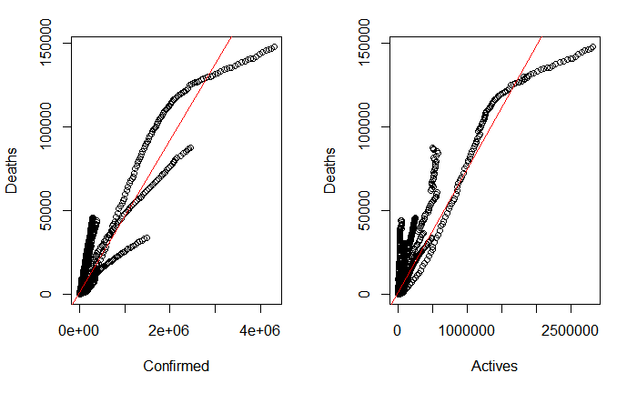

```r
plot(df$Deaths~df$Active, xlab="Actives", ylab="Deaths")
abline(lm(df$Deaths~df$Active), col="red")
```

##Separating the data into train/test

```r
set.seed(1234)
i <- sample(1:nrow(df), nrow(df)*0.60, replace=FALSE)
train <- df[i,]
test <- df[-i,]
```

#Tuning the best SVM Model

tune runs the svm algorithm in different levels of cost. From all of the costs, it will then choose the best cost to produce the best model. The kernel used is linear.

```r
tune_svm1 <- tune(svm, Deaths~., data = train, kernel="linear",
                  ranges= list(cost=c(0.001, 0.01, 0.1, 1, 5, 10, 100)))

summary(tune_svm1)
```

```
Parameter tuning of ‘svm’:

- sampling method: 10-fold cross validation

- best parameters:
```

|  | cost |
| --- | --- |
|  | 0.01 |

```
- best performance: 14233377

- Detailed performance results:
```

| cost | error | dispersion |
| --- | --- | --- |
| 1e-03 | 14544803 | 2413033 |
| 1e-02 | 14233377 | 2590483 |
| 1e-01 | 14329677 | 2650122 |
| 1e+00 | 14345759 | 2670475 |
| 5e+00 | 14345668 | 2670146 |
| 1e+01 | 14345883 | 2669485 |
| 1e+02 | 14339537 | 2669067 |

```
NA
```

##Predicting using the best SVM model

```r
pred <- predict(tune_svm1$best.model, newdata=test)
cor_svm1_tune <- cor(pred, test$Deaths)
mse_svm1_tune <- mean((pred - test$Deaths)^2)
print(paste("Correlation = ", cor_svm1_tune))
```

```
[1] "Correlation =  0.944067190684838"
```

```r
print(paste("MSE = ", mse_svm1_tune))
```

```
[1] "MSE =  9946191.8543313"
```

As it turns out, the model had a correlation of 0.944, which is quite high.

###Linear regression using the old model

```r
lm1 <- lm(Deaths~., data=train)
pred <- predict(lm1, newdata=test)
cor_lm1 <- cor(pred, test$Deaths)
mse_lm1 <- mean((pred-test$Deaths)^2)
```

```r
pred1 <- predict(lm1, newdata=test)
cor1 <- cor(pred1, test$Deaths)
mse1 <- mean((pred1-test$Deaths)^2)
rmse1 <- sqrt(mse1)

print(paste('correlation:', cor1))
```

```
[1] "correlation: 0.944353857286888"
```

```r
print(paste('mse:', mse1))
```

```
[1] "mse: 9517618.29562732"
```

```r
print(paste('rmse:', rmse1))
```

```
[1] "rmse: 3085.06374255498"
```

The common method for linear regression gives a correlation of 0.9443, similar but slightly higher than the linear SVM model created.

### Residuals for the linear model of deaths and confirmed

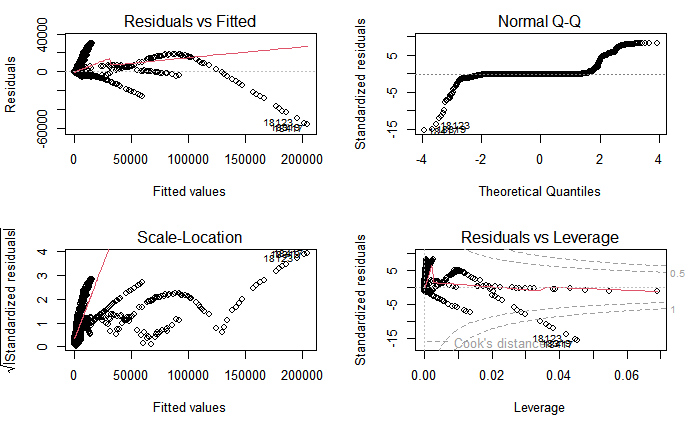

```r
par(mfrow=c(2,2))
plot(lm1)
```

###SVM With polynomial kernels

The polynomial kernel for SVM allows for a change in the line it fits the data to. Instead of being linear, it allows for some of the data that would not fit into the linear kernel to be included and theoretically may lead to a higher correlation.

I first run a trial version of the polynomial kernel with a cost of 10

```r
svm2 <- svm(Deaths~., data=train, kernel="polynomial", cost=10, scale=TRUE)
```

```
WARNING: reaching max number of iterations
```

```r
summary(svm2)
```

```
Call:
svm(formula = Deaths ~ ., data = train, kernel = "polynomial", cost = 10, scale = TRUE)


Parameters:
   SVM-Type:  eps-regression
 SVM-Kernel:  polynomial
       cost:  10
     degree:  3
      gamma:  0.5
     coef.0:  0
    epsilon:  0.1


Number of Support Vectors:  1841
```

##Test Polynomial SVM

```r
predpol <- predict(svm2, newdata=test)
cor_svm1_tune_pol <- cor(predpol, test$Deaths)
mse_svm1_tune_pol <- mean((predpol - test$Deaths)^2)
print(paste("Correlation = ", cor_svm1_tune_pol))
```

```
[1] "Correlation =  0.796520168589124"
```

```r
print(paste("MSE = ", mse_svm1_tune_pol))
```

```
[1] "MSE =  740191559.381883"
```

Testing the model, we see it has a low correlation compared to the other models, which is why we now tune the model to see if there’s a better cost to use for the model.

##Tuning the best SVM model with a polynomial Kernel

We tune the model to see which cost is better.

```r
tune_svm1 <- tune(svm, Deaths~., data = train, kernel="polynomial",
                  ranges= list(cost=c(0.001, 0.01, 0.1, 1, 5, 10, 100)))
```

[output not shown]

[output cut: 28 more lines]

[output not shown]

```r
summary(tune_svm1)
```

```
Parameter tuning of ‘svm’:

- sampling method: 10-fold cross validation

- best parameters:
```

|  | cost |
| --- | --- |
|  | 0.1 |

```
- best performance: 45062241

- Detailed performance results:
```

| cost | error | dispersion |
| --- | --- | --- |
| 1e-03 | 54709884 | 25474206 |
| 1e-02 | 47715911 | 19890844 |
| 1e-01 | 45062241 | 23489401 |
| 1e+00 | 630121715 | 606718883 |
| 5e+00 | 2922176545 | 4953930328 |
| 1e+01 | 1093846607 | 2148196517 |
| 1e+02 | 41000803281 | 49451535940 |

```
NA
```

# Evaluate and predict the best SVM polynomial model

```r
predpoly <- predict(tune_svm1$best.model, newdata=test)
cor_svm1_tune_poly <- cor(predpoly, test$Deaths)
mse_svm1_tune_poly <- mean((predpoly - test$Deaths)^2)
print(paste("Correlation = ", cor_svm1_tune_poly))
```

```
[1] "Correlation =  0.79536431656803"
```

```r
print(paste("MSE = ", mse_svm1_tune_poly))
```

```
[1] "MSE =  32628433.9873789"
```

The model still had a low correlation.

## SVM with radial kernel

For the third model, we use the radial kernel. In this case we incorporate the use of gammas, which theoretically lower variance and would lead to better results. I also lowered the highest cost, as running it with a cost of 10 and higher implied the algorithm would run for hours.

```r
tune_svm1 <- tune(svm, Deaths~.,  data=train, kernel="radial",
ranges=list(cost=c(0.001, 0.01, 0.1, 1, 5),
gamma=c(0.5,1,2,3)))


summary(tune_svm1)
```

```
Parameter tuning of ‘svm’:

- sampling method: 10-fold cross validation

- best parameters:
```

|  | cost | gamma |
| --- | --- | --- |
|  | 5 | 1 |

```
- best performance: 5220960

- Detailed performance results:
```

| cost | gamma | error | dispersion |
| --- | --- | --- | --- |
| 0.001 | 0.5 | 92087040 | 28369892 |
| 0.010 | 0.5 | 62409224 | 22312651 |
| 0.100 | 0.5 | 28743388 | 11200519 |
| 1.000 | 0.5 | 9091175 | 2859811 |
| 5.000 | 0.5 | 6117949 | 1803263 |
| 0.001 | 1.0 | 90657117 | 28175498 |
| 0.010 | 1.0 | 62626624 | 22663336 |
| 0.100 | 1.0 | 33753588 | 13273573 |
| 1.000 | 1.0 | 10866191 | 4086141 |
| 5.000 | 1.0 | 5220960 | 1530995 |

[output cut: 10 more lines]

```
NA
```

## Evaluate and predict radial svm model

We evaluate the best model, which was the one with a cost of 5 and gamma of 1.

```r
pred_radial <- predict(tune_svm1$best.model, newdata=test)
cor_svm1_tune_radial <- cor(pred_radial, test$Deaths)
mse_svm1_tune_radial <- mean((pred_radial - test$Deaths)^2)
print(paste("Correlation = ", cor_svm1_tune_radial))
```

```
[1] "Correlation =  0.982319569312726"
```

```r
print(paste("MSE = ", mse_svm1_tune_radial))
```

```
[1] "MSE =  3199751.14110407"
```

The correlation of the model is 0.98, much higher than the past models.

## Conclusion data

Looking back, we can see that the radial kernel SVM performed the best out of all the algorithms. I believe the inclusion of the gamma parameter increased highly the correlation by lowering the bias. The worst performing algorithm was the polynomial kernel, having a correlation lower than 0.8, while the other algorithms both had a correlation of 0.94, which is good.